```r
options(OutDec = ".") # Asegurar punto decimal en este chunk

# Establecer semilla aleatoria para reproducibilidad
set.seed(sample(1:10000, 1))

# --- Aleatorización de Parámetros ---

# 1. Dimensiones del cilindro
radio <- sample(2:10, 1) # Radio entero entre 2 y 10
altura <- sample(5:20, 1) # Altura entera entre 5 y 20
# Asegurar que altura sea significativamente diferente del radio
while(abs(radio - altura) < 3) {
  altura <- sample(5:20, 1)
}

# 2. Unidades de medida
unidades_lista <- c("cm", "m", "mm", "pulgadas")
unidad <- sample(unidades_lista, 1)
unidad_tex <- ifelse(unidad == "pulgadas", "\\text{pulgadas}", paste0("\\text{", unidad, "}")) # Para LaTeX

# 3. Objeto cilíndrico
objetos_lista <- c("vaso", "cilindro", "tanque", "recipiente", "tubo", "envase")
objeto <- sample(objetos_lista, 1)

# 4. Contexto/Actor
actores_lista <- c("Un estudiante", "Un ingeniero", "Un diseñador", "Un arquitecto", "Un técnico", "Una persona")
actor <- sample(actores_lista, 1)

# 5. Términos descriptivos
termino_base <- sample(c("base circular", "base redonda", "tapa circular"), 1)
termino_radio <- sample(c("radio", "radio de la base"), 1)
termino_altura <- sample(c("altura", "longitud"), 1)
termino_figura <- sample(c("la figura", "el diagrama", "el esquema", "la ilustración"), 1)
termino_operacion <- sample(c("operación", "expresión", "fórmula", "cálculo"), 1)
termino_resultado <- sample(c("resultado", "valor", "número"), 1)

# --- Cálculos ---
volumen <- pi * radio^2 * altura
area_base <- pi * radio^2
perimetro_base <- 2 * pi * radio
area_lateral <- 2 * pi * radio * altura

# 6. Formato del resultado mostrado en la operación
decimales_mostrados <- sample(1:3, 1) # Número de decimales a mostrar
resultado_mostrado <- format(round(volumen, decimales_mostrados), nsmall = decimales_mostrados)
# Reemplazar punto por coma si se desea (estilo común en español)
# resultado_mostrado_coma <- gsub("\\.", ",", resultado_mostrado)
# Mantener punto por consistencia con options(OutDec = ".")
resultado_mostrado_str <- resultado_mostrado

# Crear la cadena de la operación como se muestra en la imagen
# Usar glue para facilitar la inserción de variables
operacion_str <- glue("\\pi \\times {radio}^2 \\times {altura} = {resultado_mostrado_str}")
# La variable operacion_html se elimina ya que causaba problemas con LaTeX

# --- Opciones de Respuesta y Solución ---

# 7. Crear opciones de respuesta (una correcta, tres distractores)
opcion_correcta_texto <- glue("Al volumen del {objeto}.")
opcion_area_base_texto <- glue("Al área de la {termino_base} del {objeto}.")
opcion_perimetro_base_texto <- glue("Al perímetro de la {termino_base} del {objeto}.")
opcion_area_lateral_texto <- glue("Al área lateral del {objeto}.")

# 8. Aleatorizar un distractor adicional (opcional, si se quiere variar más)
#    Podría ser, por ejemplo, el área total (2*area_base + area_lateral)
# area_total = 2 * area_base + area_lateral
# opcion_area_total_texto = glue("Al área total del {objeto}.")

# Crear lista de opciones
opciones <- c(
  opcion_correcta_texto,
  opcion_area_base_texto,
  opcion_perimetro_base_texto,
  opcion_area_lateral_texto
)

# 9. Aleatorizar el orden de las opciones
orden_opciones <- sample(1:length(opciones))
opciones_aleatorias <- opciones[orden_opciones]

# Crear el vector de solución para r-exams (1 para la correcta, 0 para las demás)
solucion <- rep(0, length(opciones))
solucion[which(orden_opciones == 1)] <- 1 # La opción correcta es la primera en la lista original
solucion_vector <- paste(solucion, collapse = "")

# --- Variables para la Solución Detallada ---
# Formatear los valores calculados para mostrarlos en la solución
volumen_fmt <- format(round(volumen, 2), nsmall = 2)
area_base_fmt <- format(round(area_base, 2), nsmall = 2)
perimetro_base_fmt <- format(round(perimetro_base, 2), nsmall = 2)
area_lateral_fmt <- format(round(area_lateral, 2), nsmall = 2)

# 10. Aleatorizar colores para el diagrama (si se genera)
colores_base <- c("blue", "green", "red", "purple", "orange", "gray")
color_cilindro <- sample(colores_base, 1)
color_dimensiones <- sample(colores_base[colores_base != color_cilindro], 1)

# --- Validación (simple) ---
stopifnot(radio > 0, altura > 0) # Asegurar dimensiones positivas
stopifnot(length(opciones) == 4) # Asegurar 4 opciones
stopifnot(sum(solucion) == 1) # Asegurar una única respuesta correcta
```

# Question

Un técnico tiene un vaso de forma cilíndrica. El vaso tiene una base circular de radio 4 cm y una longitud de 14 cm, como se muestra en la ilustración.

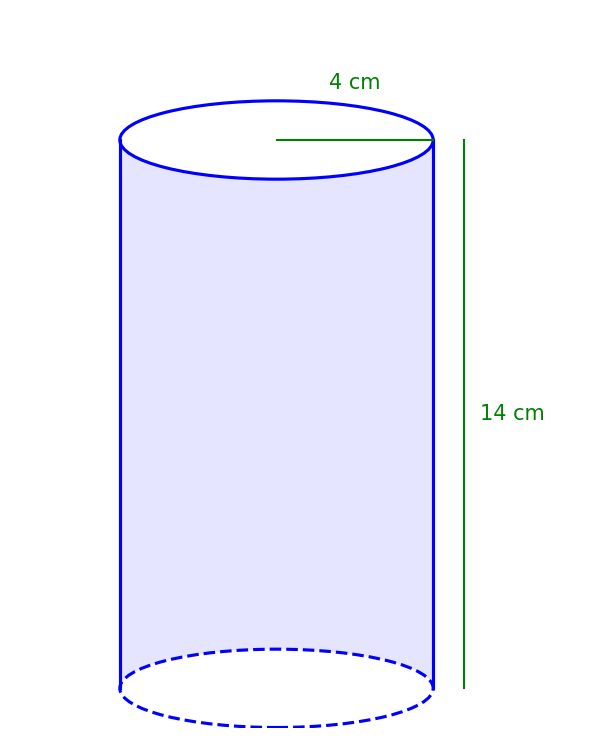

A partir de la información anterior, Un técnico plantea la siguiente operación:

$$\pi \times 4^2 \times 14 = 703.7$$

¿A qué corresponde el valor de la anterior operación?

## Answerlist

- Al perímetro de la base circular del vaso.
- Al área lateral del vaso.
- Al área de la base circular del vaso.
- Al volumen del vaso.

# Solution

La operación mostrada es $\pi \times 4^2 \times 14 = 703.7$.

Analicemos las fórmulas para las diferentes propiedades de un cilindro con radio $r = 4$ cm y longitud $h = 14$ cm:

- **Volumen (V):** Es el espacio que ocupa el vaso. Se calcula como el área de la base multiplicada por la altura: $V = \pi \times r^2 \times h = \pi \times (4)^2 \times 14 \approx 703.72$ (cm$^3$)
- **Área de la base circular (A_b):** Es el área de uno de los círculos que forman las bases: $A_b = \pi \times r^2 = \pi \times (4)^2 \approx 50.27$ (cm$^2$)
- **Perímetro de la base circular (P_b):** Es la longitud de la circunferencia de la base: $P_b = 2 \times \pi \times r = 2 \times \pi \times 4 \approx 25.13$ (cm)
- **Área Lateral (A_l):** Es el área de la superficie curva del vaso: $A_l = 2 \times \pi \times r \times h = 2 \times \pi \times 4 \times 14 \approx 351.86$ (cm$^2$)

La operación mostrada ($\pi \times 4^2 \times 14 = 703.7$) sigue la estructura de la fórmula del **volumen** ($V = \pi \times r^2 \times h$).

Por lo tanto, el valor corresponde al volumen del vaso.

## Answerlist

- False
- False
- False
- True

# Meta-information

exname: volumen_cilindro_interpretacion extype: schoice exsolution: 0001 exshuffle: TRUE # Aleatorizar el orden de las opciones A, B, C, D exsection: Geometría/Volumen/Interpretación de fórmulas exextra[Type]: Calculation exextra[Level]: Medium exextra[Language]: Spanish exextra[Keywords]: cilindro, volumen, área, perímetro, fórmula, interpretación, geometría exextra[Radio]: 4 exextra[Altura]: 14 exextra[Unidad]: cm exextra[Objeto]: vaso